# Final_Project

## [HOME](http://MurderousPolyhedron.github.io/) | [ABOUT ME](http://MurderousPolyhedron.github.io/About_Me/) | [CV](http://MurderousPolyhedron.github.io/CV/) | [PROGRAMMING](http://MurderousPolyhedron.github.io/Programming/) | [RESEARCH](http://MurderousPolyhedron.github.io/Research/) [Exam 3](http://MurderousPolyhedron.github.io/Exam_3/) | [Final](http://MurderousPolyhedron.github.io/Final_Project/) | [Data_Course](https://github.com/MurderousPolyhedron/Data_Course_RAAB)

# Welcome to my descent into madness aka my Final Project

### Before we start off on this here is the initial code of tidying some of the data. Now you may be asking why isn’t this just in the code? Well the initial data was 286.07mb big, even when compressing it into a zip file it was still 199mb large. So obviously these files are much to large to put on github without paying their premium service. As a college student I can’t justify that cost. So I will be providing the initial code to demonstrate what I did to tidy the data into a much more manageable size along with a link to download the original dataset. The raw data can be found here.

### https://drive.google.com/open?id=1MbG2a-vQtTclHgn8-PCwIrx3CB7xzb0_

### Here is the code. Funnily enough this code is the third version as I had to build this whole thing from the ground up 3 times.

```
library(lubridate)
library(tidyverse)
df <- read.csv("../UL_BiologicalData_1.csv")
class(df$ActivityStartDate)
df$ActivityStartDate <- as.Date(df$ActivityStartDate, format = "%m/%d/%Y")
df2 <- subset(df, ActivityStartDate > "2016-05-24" & ActivityStartDate < "2017-08-26")
df3 <- subset(df2,
              select = c("ActivityStartDate","ActivityStartTime.Time",
                         "ActivityEndDate","ActivityEndTime.Time",
                         "ActivityDepthHeightMeasure.MeasureValue",
                         "MonitoringLocationIdentifier",
                         "ActivityLocation.LatitudeMeasure",
                         "ActivityLocation.LongitudeMeasure"))
write.csv(df3,file = "../UL_BiologicalData_cleaned_2.csv")
```

### So first is a simple summary of the Data which looks innocent enough. Now this is a summary of only E.Coli growth. Now this seems like the best place to start off with the real introduction of to the data I was working with. So my goal of this was to combine a dataset of all of utah weather and a dataset of E.Coli growth from the field collected by my Research Mentor. All in the hopes to find a pattern with E.coli growth and rainfall. This would however prove extremely difficult.

```
##    Min. 1st Qu.  Median    Mean 3rd Qu.    Max.    NA's
##    0.99    1.00    3.06  218.24  179.91 2419.57    5339
```

### Followed up with some extensive graphing of the combined dataframes. It doesn’t look good.

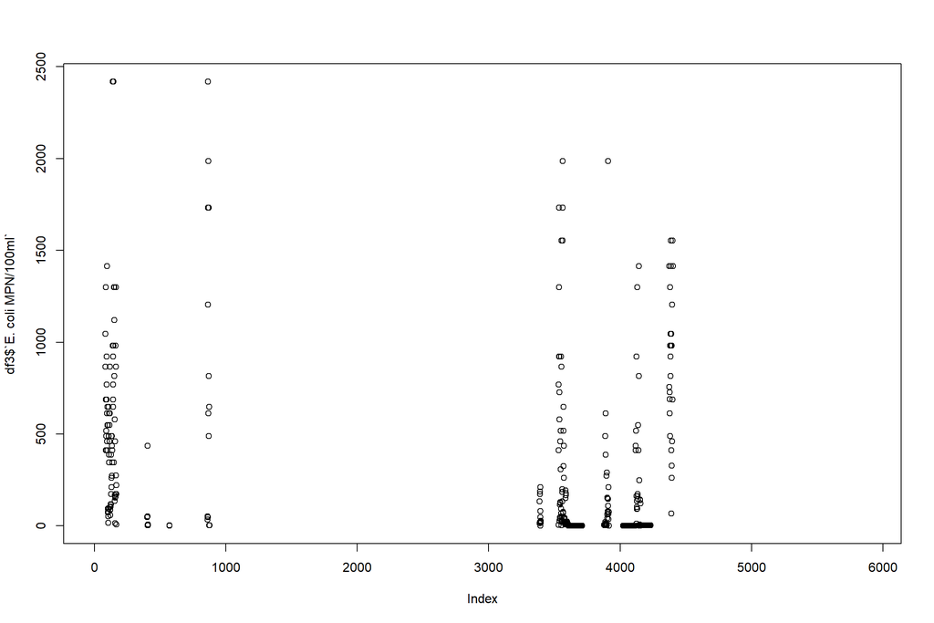

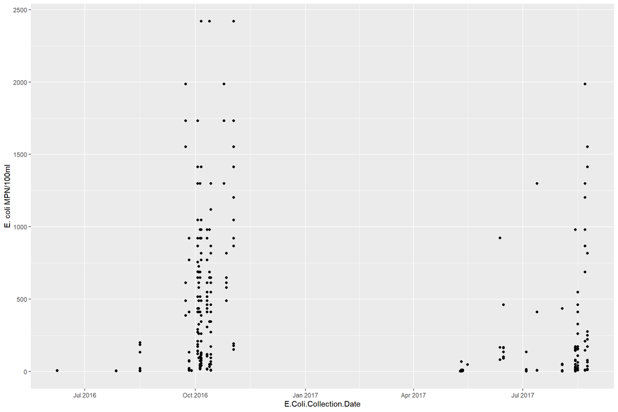

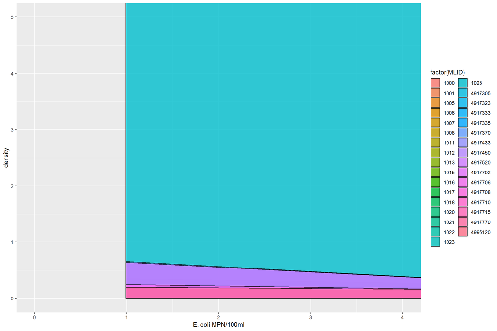

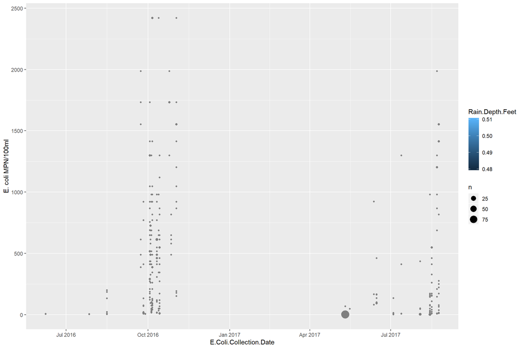

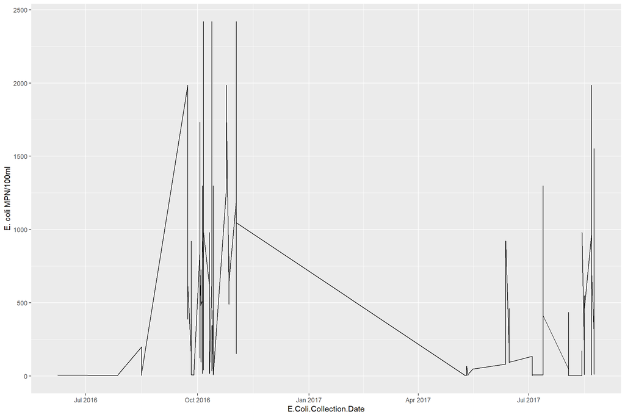

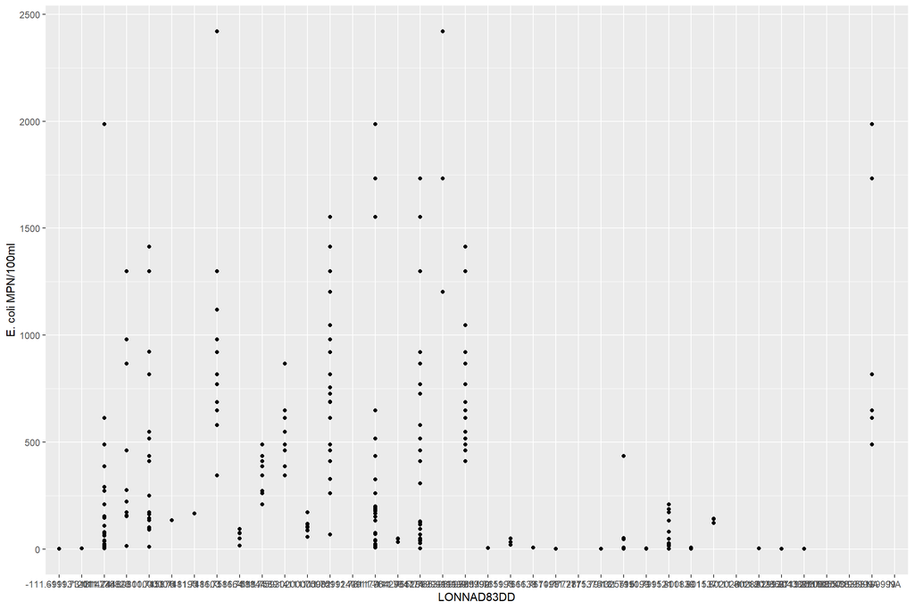

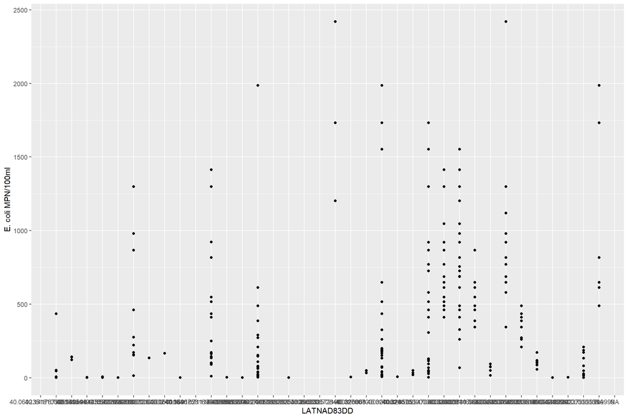

### So I didn’t even bother including the many and many plots that didn’t even show anything or were so ugly they melted your eyes upon seeing them. I am also aware these are also pretty ugly but the data being shown is so ugly as well. Why polish a turd type of thing. So at this was about the point that I rebuilt the subsetting from the ground up 3 separate times. As I was continously met with a sea of NA values in every column of the Utah Weather dataset. At first I thought it was my subsetting but it turns out the Utah Weather dataset is just shite, even more shite than several initial glances. It wasn’t until I was deep in this ocean of fuckery that I realized how bad it was. Even eliminating NA values did not save me as it would leave me with a desert of nothing once taken out.

```
##      MLID                 X          Rain.Start.Date Rain.Start.Time
##  Length:322         Min.   :1717   2016-07-25:  3    10:28:00:  2
##  Class :character   1st Qu.:2239   2016-07-20:  1    10:00:00:  1
##  Mode  :character   Median :3278   2016-08-10:  1    10:25:00:  1
##                     Mean   :3351   2016-09-21:  1    13:21:00:  1
##                     3rd Qu.:4475   2016-09-26:  1    13:32:00:  1
##                     Max.   :4878   (Other)   :  6    (Other) :  7
##                     NA's   :309    NA's      :309    NA's    :309
##  Rain.End.Date         Rain.End.Time Rain.Depth.Feet Rain.Latitude
##  Min.   :2016-08-10           : 12   Min.   :0.5     Min.   :40.44
##  1st Qu.:2016-08-10   10:15:59:  0   1st Qu.:0.5     1st Qu.:40.44
##  Median :2016-08-10   11:30:59:  0   Median :0.5     Median :40.44
##  Mean   :2016-08-10   13:05:59:  0   Mean   :0.7     Mean   :40.44
##  3rd Qu.:2016-08-10   15:15:59:  1   3rd Qu.:1.0     3rd Qu.:40.44
##  Max.   :2016-08-10   NA's    :309   Max.   :1.0     Max.   :40.44
##  NA's   :321                         NA's   :317     NA's   :318
##  Rain.Longitude   Collection.Location E.Coli.Collection.Date
##  Min.   :-111.7   Length:322          Min.   :2016-06-08 00:00:00
##  1st Qu.:-111.7   Class :character    1st Qu.:2016-10-05 00:00:00
##  Median :-111.7   Mode  :character    Median :2016-10-14 00:00:00
##  Mean   :-111.7                       Mean   :2017-01-30 11:20:23
##  3rd Qu.:-111.7                       3rd Qu.:2017-08-03 00:00:00
##  Max.   :-111.7                       Max.   :2017-08-24 00:00:00
##  NA's   :318                          NA's   :13
##  E.Coli.Collection.Time E. coli MPN/100ml  LONNAD83DD         LATNAD83DD
##  Length:322             Min.   :   0.99   Length:322         Length:322
##  Class :character       1st Qu.:  23.00   Class :character   Class :character
##  Mode  :character       Median : 172.16   Mode  :character   Mode  :character
##                         Mean   : 420.09
##                         3rd Qu.: 622.06
##                         Max.   :2419.57
##                         NA's   :30
```

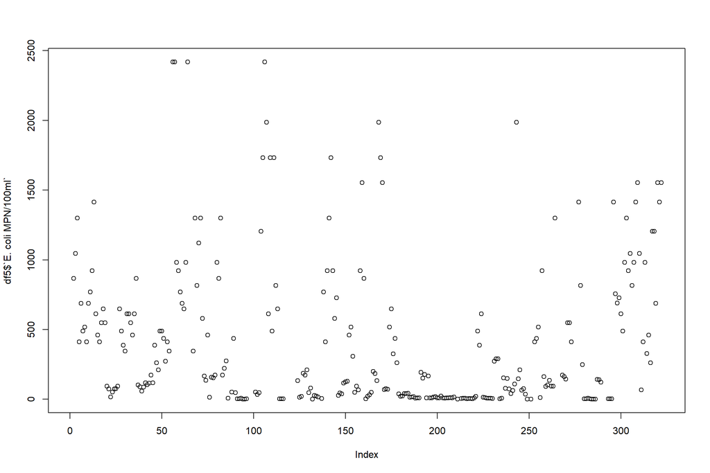

```r
plot(df5$`E. coli MPN/100ml`)
```

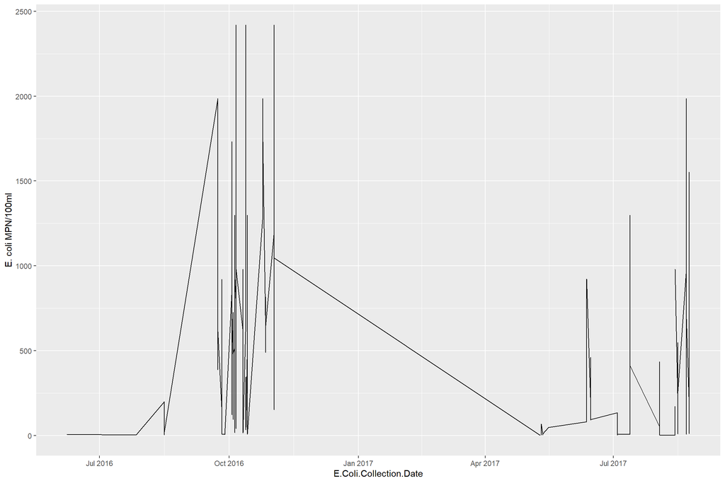

```r
ggplot(df5,aes(x=E.Coli.Collection.Date, y=`E. coli MPN/100ml`)) + geom_line()
```

### It didn’t work. In fact it looks the same.So at this point I had clearly hit the realization that it was completely unworkable or I was complete shit at coding. Now I won’t disagree I am still very much an ameteur, however I’m pretty confidant the Utah Weather dataset is 100% fuck. The other one also needs some work but I don’t know who collected it specifically so I got to be polite. I also remember early on that Dr. Zahn had said sometimes datasets are so poorly recorded we can’t do anything with them and that he has had that experience several times. So not disheartening, I just pick myself up and start over again with a new dataset…however this conclusion was reached 4/27/2020 at 1am…so I chose to just grind my face against the grindstone and at least demonstrate I knew some of the skills we learned in class. So I moved to modeling.

```r
mod1.0 <- aov(`E. coli MPN/100ml` ~ Rain.Start.Date, data = df3)
mod1.1 <- aov(`E. coli MPN/100ml` ~ MLID, data = df3)

mod1.2 <- lm(`E. coli MPN/100ml` ~ Rain.Start.Date, data = df3)
mod1.3 <- lm(`E. coli MPN/100ml` ~ MLID, data = df3)
mod1.4 <- lm(`E. coli MPN/100ml` ~ E.Coli.Collection.Date, data = df3)

mod2.0 <- aov(`E. coli MPN/100ml` ~ MLID, data = df5)
mod2.1 <- lm(`E. coli MPN/100ml` ~ MLID, data = df5)

mod1.7 <- lm(`E. coli MPN/100ml` ~ MLID: E.Coli.Collection.Date, data = df3)
```

```r
summary(mod1.0)
```

```
##                  Df Sum Sq Mean Sq F value Pr(>F)
## Rain.Start.Date   1   0.48  0.4783   0.572   0.45
## Residuals       273 228.11  0.8356
## 5628 observations deleted due to missingness
```

```r
summary(mod1.1)
```

```
##              Df   Sum Sq Mean Sq F value Pr(>F)
## MLID         32 64314274 2009821   26.16 <2e-16 ***
## Residuals   531 40800396   76837
## ---
## Signif. codes:  0 '***' 0.001 '**' 0.01 '*' 0.05 '.' 0.1 ' ' 1
## 5339 observations deleted due to missingness
```

```r
summary(mod1.2)
```

```
##
## Call:
## lm(formula = `E. coli MPN/100ml` ~ Rain.Start.Date, data = df3)
##
## Residuals:
##     Min      1Q  Median      3Q     Max
## -0.5932 -0.5832 -0.5097  1.4768  1.5603
##
## Coefficients:
##                           Estimate Std. Error t value Pr(>|t|)
## (Intercept)                1.58319    0.07617  20.784   <2e-16 ***
## Rain.Start.Date2016-06-30 -0.08350    0.11037  -0.757     0.45
## ---
## Signif. codes:  0 '***' 0.001 '**' 0.01 '*' 0.05 '.' 0.1 ' ' 1
##
## Residual standard error: 0.9141 on 273 degrees of freedom
##   (5628 observations deleted due to missingness)
## Multiple R-squared:  0.002092,   Adjusted R-squared:  -0.001563
## F-statistic: 0.5724 on 1 and 273 DF,  p-value: 0.45
```

```r
summary(mod1.3)
```

```
##
## Call:
## lm(formula = `E. coli MPN/100ml` ~ MLID, data = df3)
##
## Residuals:
##     Min      1Q  Median      3Q     Max
## -853.79  -51.43    0.00    0.00 1829.21
##
## Coefficients:
##             Estimate Std. Error t value Pr(>|t|)
## (Intercept)   708.09      65.34  10.838  < 2e-16 ***
## MLID1001     -640.04     123.47  -5.184 3.10e-07 ***
## MLID1005     -149.71     109.33  -1.369 0.171463
## MLID1006     -601.10     113.16  -5.312 1.60e-07 ***
## MLID1007     -341.64     113.16  -3.019 0.002659 **
## MLID1008      472.29      96.91   4.874 1.45e-06 ***
## MLID1011     -557.19     206.61  -2.697 0.007222 **
## MLID1012     -274.09     106.08  -2.584 0.010041 *
## MLID1013     -700.54     284.79  -2.460 0.014218 *
## MLID1015     -617.58     130.67  -4.726 2.93e-06 ***
## MLID1016     -706.41     172.86  -4.087 5.06e-05 ***
## MLID1017     -664.30     172.86  -3.843 0.000136 ***
## MLID1018     1077.17     172.86   6.231 9.42e-10 ***
## MLID1020      591.62     206.61   2.863 0.004356 **
## MLID1021      402.57     206.61   1.948 0.051885 .
## MLID1022      566.56     206.61   2.742 0.006309 **
## MLID1023      -59.27     284.79  -0.208 0.835206
## MLID1025     -705.04     172.86  -4.079 5.22e-05 ***
## MLID4917305  -630.45     103.30  -6.103 2.01e-09 ***
## MLID4917323  -702.62     284.79  -2.467 0.013933 *
## MLID4917333  -234.63      84.35  -2.782 0.005600 **
## MLID4917335  -500.62      77.31  -6.476 2.15e-10 ***
## MLID4917370  -707.09      70.57 -10.020  < 2e-16 ***
## MLID4917433  -551.02      80.02  -6.886 1.63e-11 ***
## MLID4917450  -706.50     284.79  -2.481 0.013419 *
## MLID4917520  -707.10      71.32  -9.915  < 2e-16 ***
## MLID4917702  -292.14      89.04  -3.281 0.001102 **
## MLID4917706  -705.42     123.47  -5.713 1.85e-08 ***
## MLID4917708  -573.44     172.86  -3.317 0.000971 ***
## MLID4917710  -706.06     284.79  -2.479 0.013476 *
## MLID4917715  -706.07     284.79  -2.479 0.013474 *
## MLID4917770  -705.03      72.95  -9.665  < 2e-16 ***
## MLID4995120   212.86      84.35   2.524 0.011908 *
## ---
## Signif. codes:  0 '***' 0.001 '**' 0.01 '*' 0.05 '.' 0.1 ' ' 1
##
## Residual standard error: 277.2 on 531 degrees of freedom
##   (5339 observations deleted due to missingness)
## Multiple R-squared:  0.6118, Adjusted R-squared:  0.5885
## F-statistic: 26.16 on 32 and 531 DF,  p-value: < 2.2e-16
```

```r
summary(mod1.4)
```

```
##
## Call:
## lm(formula = `E. coli MPN/100ml` ~ E.Coli.Collection.Date, data = df3)
##
## Residuals:
##     Min      1Q  Median      3Q     Max
## -607.97 -139.47 -139.46   18.78 2013.20
##
## Coefficients:
##                          Estimate Std. Error t value Pr(>|t|)
## (Intercept)             2.435e+04  2.466e+03   9.875   <2e-16 ***
## E.Coli.Collection.Date -1.620e-05  1.655e-06  -9.787   <2e-16 ***
## ---
## Signif. codes:  0 '***' 0.001 '**' 0.01 '*' 0.05 '.' 0.1 ' ' 1
##
## Residual standard error: 399.8 on 562 degrees of freedom
##   (5339 observations deleted due to missingness)
## Multiple R-squared:  0.1456, Adjusted R-squared:  0.1441
## F-statistic: 95.79 on 1 and 562 DF,  p-value: < 2.2e-16
```

```r
summary(mod1.7)
```

```
##
## Call:
## lm(formula = `E. coli MPN/100ml` ~ MLID:E.Coli.Collection.Date,
##     data = df3)
##
## Residuals:
##     Min      1Q  Median      3Q     Max
## -835.68  -43.02    0.00    0.00 1906.04
##
## Coefficients:
##                                      Estimate Std. Error t value Pr(>|t|)
## (Intercept)                         6.399e+03  2.542e+03   2.518   0.0121 *
## MLID1000:E.Coli.Collection.Date    -3.856e-06  1.723e-06  -2.238   0.0256 *
## MLID1001:E.Coli.Collection.Date    -4.290e-06  1.724e-06  -2.489   0.0131 *
## MLID1005:E.Coli.Collection.Date    -3.957e-06  1.723e-06  -2.297   0.0220 *
## MLID1006:E.Coli.Collection.Date    -4.263e-06  1.723e-06  -2.474   0.0137 *
## MLID1007:E.Coli.Collection.Date    -4.087e-06  1.723e-06  -2.372   0.0180 *
## MLID1008:E.Coli.Collection.Date    -3.535e-06  1.722e-06  -2.053   0.0406 *
## MLID1011:E.Coli.Collection.Date    -4.170e-06  1.701e-06  -2.451   0.0146 *
## MLID1012:E.Coli.Collection.Date    -3.970e-06  1.693e-06  -2.346   0.0194 *
## MLID1013:E.Coli.Collection.Date    -4.261e-06  1.704e-06  -2.500   0.0127 *
## MLID1015:E.Coli.Collection.Date    -4.200e-06  1.694e-06  -2.480   0.0135 *
## MLID1016:E.Coli.Collection.Date    -4.260e-06  1.696e-06  -2.512   0.0123 *
## MLID1017:E.Coli.Collection.Date    -4.305e-06  1.725e-06  -2.496   0.0129 *
## MLID1018:E.Coli.Collection.Date    -3.122e-06  1.723e-06  -1.812   0.0706 .
## MLID1020:E.Coli.Collection.Date    -3.452e-06  1.725e-06  -2.001   0.0460 *
## MLID1021:E.Coli.Collection.Date    -3.580e-06  1.725e-06  -2.075   0.0385 *
## MLID1022:E.Coli.Collection.Date    -3.469e-06  1.725e-06  -2.010   0.0449 *
## MLID1023:E.Coli.Collection.Date    -3.892e-06  1.730e-06  -2.249   0.0249 *
## MLID1025:E.Coli.Collection.Date    -4.257e-06  1.695e-06  -2.512   0.0123 *
## MLID4917305:E.Coli.Collection.Date -4.250e-06  1.709e-06  -2.486   0.0132 *
## MLID4917323:E.Coli.Collection.Date -4.278e-06  1.711e-06  -2.501   0.0127 *
## MLID4917333:E.Coli.Collection.Date -4.005e-06  1.718e-06  -2.331   0.0201 *
## MLID4917335:E.Coli.Collection.Date -4.171e-06  1.712e-06  -2.436   0.0152 *
## MLID4917370:E.Coli.Collection.Date -4.281e-06  1.701e-06  -2.517   0.0121 *
## MLID4917433:E.Coli.Collection.Date -4.203e-06  1.712e-06  -2.455   0.0144 *
## MLID4917450:E.Coli.Collection.Date -4.281e-06  1.711e-06  -2.502   0.0126 *
## MLID4917520:E.Coli.Collection.Date -4.281e-06  1.701e-06  -2.517   0.0121 *
## MLID4917702:E.Coli.Collection.Date -3.997e-06  1.699e-06  -2.353   0.0190 *
## MLID4917706:E.Coli.Collection.Date -4.261e-06  1.695e-06  -2.515   0.0122 *
## MLID4917708:E.Coli.Collection.Date -4.246e-06  1.726e-06  -2.460   0.0142 *
## MLID4917710:E.Coli.Collection.Date -4.281e-06  1.711e-06  -2.502   0.0126 *
## MLID4917715:E.Coli.Collection.Date -4.281e-06  1.711e-06  -2.502   0.0126 *
## MLID4917770:E.Coli.Collection.Date -4.280e-06  1.701e-06  -2.516   0.0122 *
## MLID4995120:E.Coli.Collection.Date -3.682e-06  1.709e-06  -2.155   0.0316 *
## ---
## Signif. codes:  0 '***' 0.001 '**' 0.01 '*' 0.05 '.' 0.1 ' ' 1
##
## Residual standard error: 276 on 530 degrees of freedom
##   (5339 observations deleted due to missingness)
## Multiple R-squared:  0.6159, Adjusted R-squared:  0.5919
## F-statistic: 25.75 on 33 and 530 DF,  p-value: < 2.2e-16
```

```r
summary(mod2.0)
```

```
##              Df   Sum Sq Mean Sq F value Pr(>F)
## MLID         32 39644769 1238899   7.865 <2e-16 ***
## Residuals   259 40800396  157530
## ---
## Signif. codes:  0 '***' 0.001 '**' 0.01 '*' 0.05 '.' 0.1 ' ' 1
## 30 observations deleted due to missingness
```

```r
summary(mod2.1)
```

```
##
## Call:
## lm(formula = `E. coli MPN/100ml` ~ MLID, data = df5)
##
## Residuals:
##     Min      1Q  Median      3Q     Max
## -853.79 -191.97  -42.42   56.58 1829.21
##
## Coefficients:
##             Estimate Std. Error t value Pr(>|t|)
## (Intercept)   708.09      93.55   7.569 6.60e-13 ***
## MLID1001     -640.04     176.79  -3.620 0.000354 ***
## MLID1005     -149.71     156.54  -0.956 0.339781
## MLID1006     -601.10     162.03  -3.710 0.000254 ***
## MLID1007     -341.64     162.03  -2.108 0.035955 *
## MLID1008      472.29     138.76   3.404 0.000770 ***
## MLID1011     -557.19     295.83  -1.883 0.060756 .
## MLID1012     -274.09     151.90  -1.804 0.072323 .
## MLID1013     -700.54     407.78  -1.718 0.087003 .
## MLID1015     -617.58     187.10  -3.301 0.001100 **
## MLID1016     -706.41     247.51  -2.854 0.004666 **
## MLID1017     -664.30     247.51  -2.684 0.007745 **
## MLID1018     1077.17     247.51   4.352 1.94e-05 ***
## MLID1020      591.62     295.83   2.000 0.046561 *
## MLID1021      402.57     295.83   1.361 0.174758
## MLID1022      566.56     295.83   1.915 0.056578 .
## MLID1023      -59.27     407.78  -0.145 0.884541
## MLID1025     -705.04     247.51  -2.849 0.004745 **
## MLID4917305  -630.45     147.92  -4.262 2.84e-05 ***
## MLID4917323  -702.62     407.78  -1.723 0.086072 .
## MLID4917333  -234.63     120.77  -1.943 0.053135 .
## MLID4917335  -500.62     110.69  -4.523 9.30e-06 ***
## MLID4917370  -707.09     407.78  -1.734 0.084104 .
## MLID4917433  -551.02     114.58  -4.809 2.57e-06 ***
## MLID4917450  -706.50     407.78  -1.733 0.084364 .
## MLID4917520  -707.10     407.78  -1.734 0.084100 .
## MLID4917702  -292.14     127.49  -2.292 0.022737 *
## MLID4917706  -705.42     176.79  -3.990 8.60e-05 ***
## MLID4917708  -573.44     247.51  -2.317 0.021294 *
## MLID4917710  -706.06     407.78  -1.731 0.084555 .
## MLID4917715  -706.07     407.78  -1.732 0.084551 .
## MLID4917770  -705.03     407.78  -1.729 0.085006 .
## MLID4995120   212.86     120.77   1.762 0.079174 .
## ---
## Signif. codes:  0 '***' 0.001 '**' 0.01 '*' 0.05 '.' 0.1 ' ' 1
##
## Residual standard error: 396.9 on 259 degrees of freedom
##   (30 observations deleted due to missingness)
## Multiple R-squared:  0.4928, Adjusted R-squared:  0.4302
## F-statistic: 7.865 on 32 and 259 DF,  p-value: < 2.2e-16
```

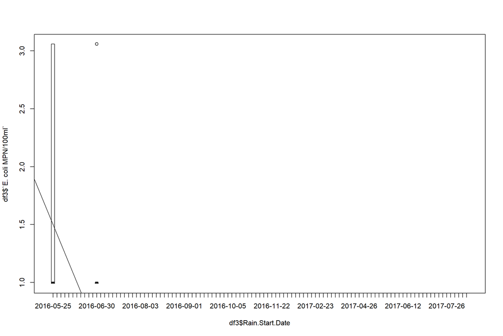

```r
plot(df3$`E. coli MPN/100ml`~ df3$Rain.Start.Date)
abline(mod1.0, col="black")
```

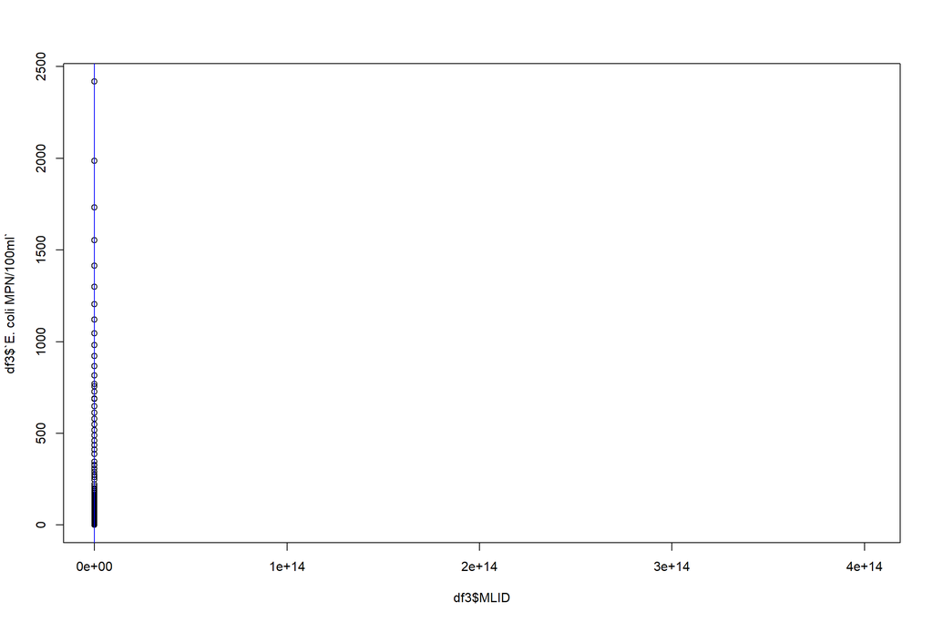

```r
plot(df3$`E. coli MPN/100ml`~ df3$MLID)
abline(mod1.1, col="blue")
```

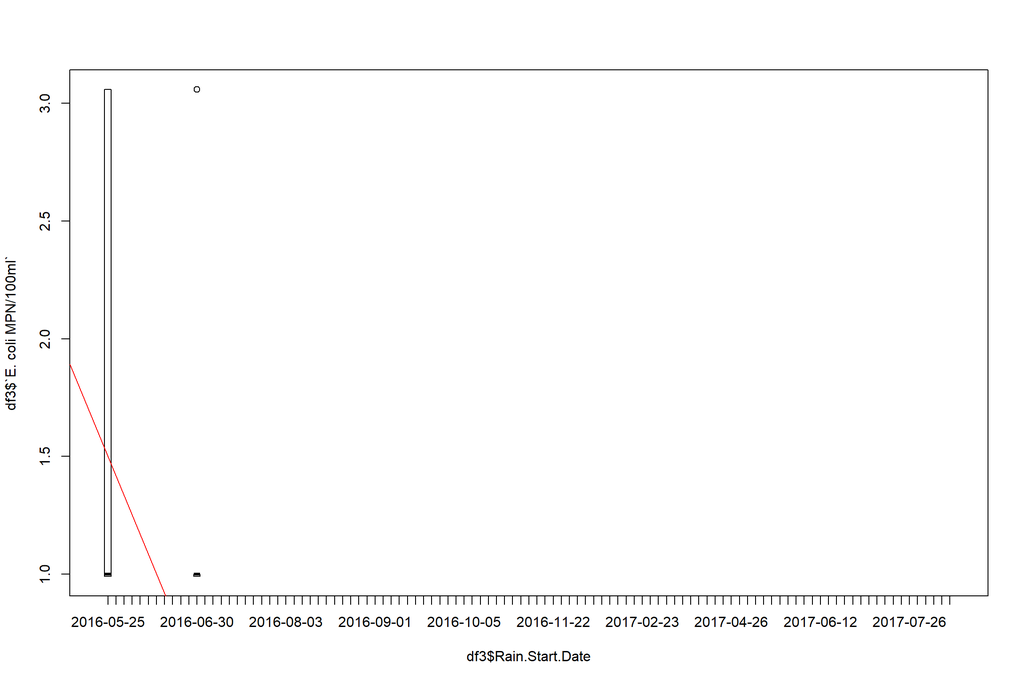

```r
plot(df3$`E. coli MPN/100ml`~ df3$Rain.Start.Date)
abline(mod1.2, col="red")
```

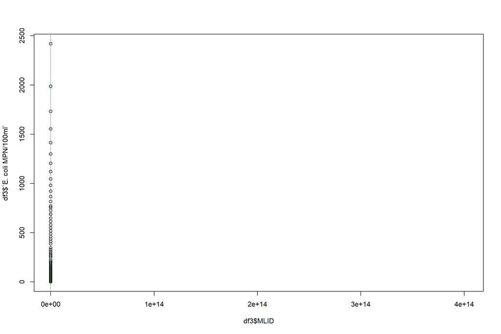

```r
plot(df3$`E. coli MPN/100ml`~ df3$MLID)
abline(mod1.3, col="green")
```

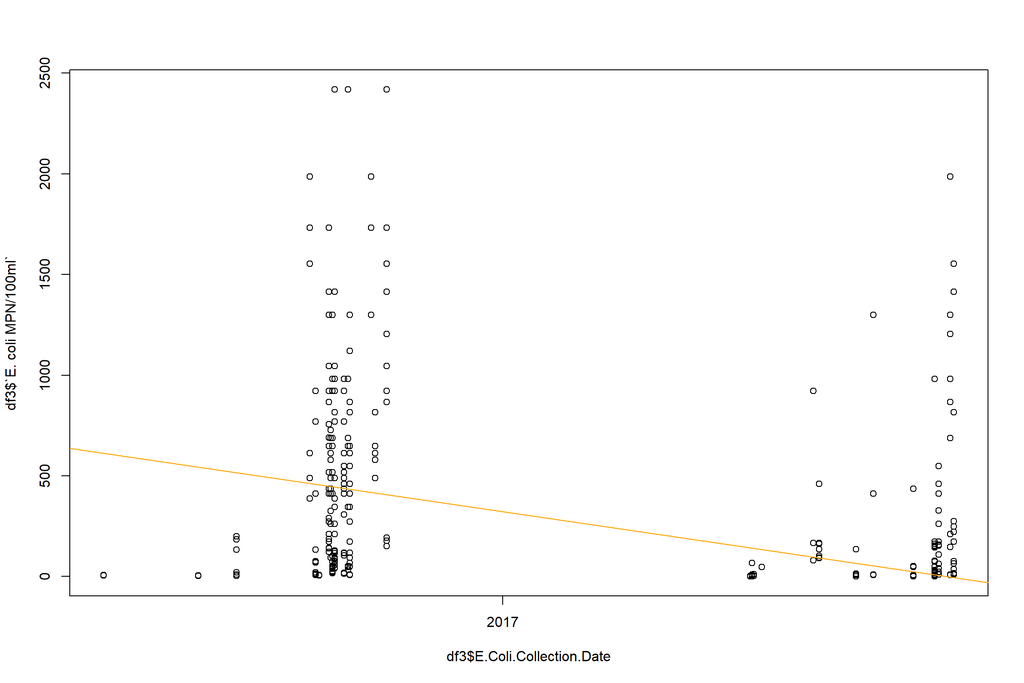

```r
plot(df3$`E. coli MPN/100ml`~ df3$E.Coli.Collection.Date)
abline(mod1.4, col="orange")
```

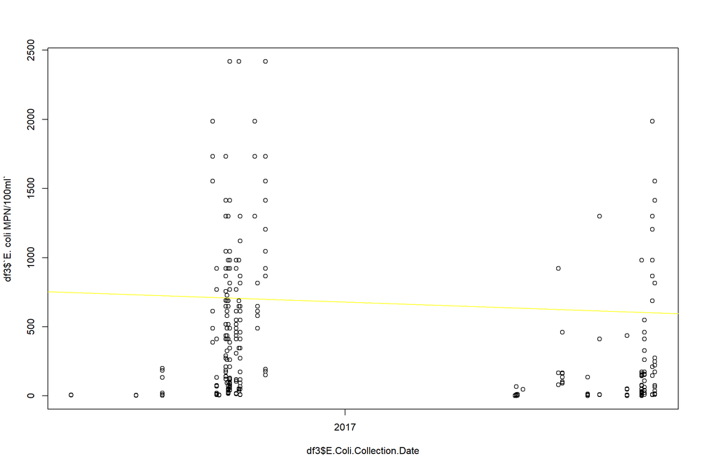

```r
plot(df3$`E. coli MPN/100ml`~ df3$E.Coli.Collection.Date)
abline(mod1.7, col="yellow")
```

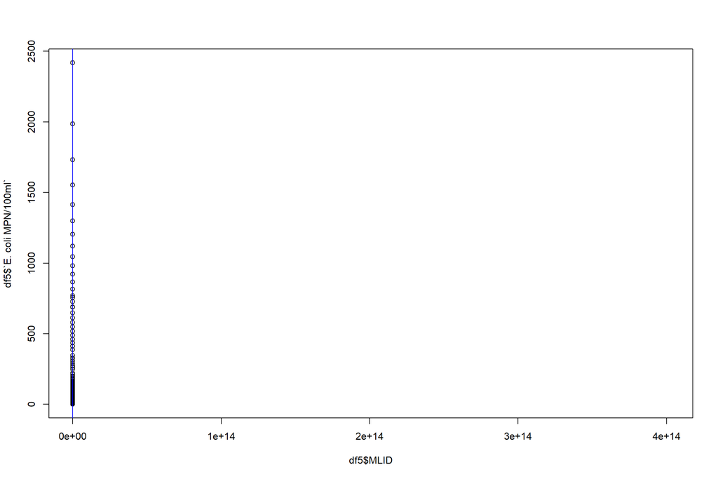

```r
plot(df5$`E. coli MPN/100ml`~ df5$MLID)
abline(mod2.0, col="black")
abline(mod2.1, col="blue")
```

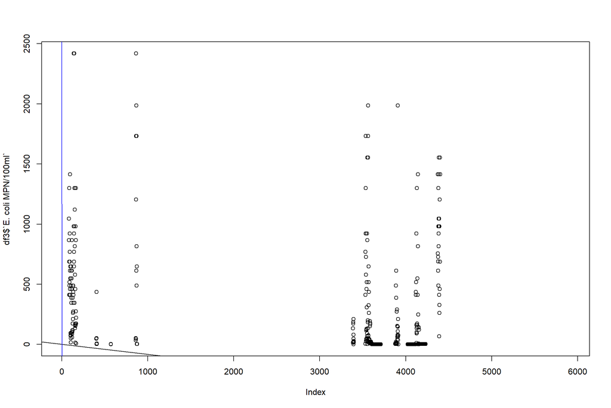

```r
plot(df3$`E. coli MPN/100ml`)
abline(mod1.0, col="black")
abline(mod1.1, col="blue")
abline(mod1.4, col="green")
abline(mod1.7, col="orange")
```

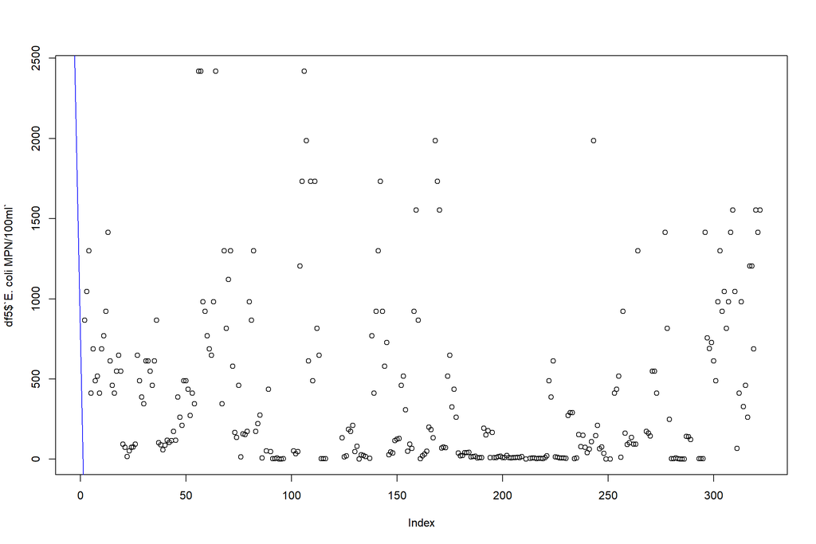

```r
plot(df5$`E. coli MPN/100ml`)
abline(mod2.0, col="black")
abline(mod2.1, col="blue")
abline(mod1.7, col="red")
```

### Hmmmm yup those models are shit but they don’t really got much to work on and I suck at modelling anyway. Time to move on to looking at residuals and adding predictions.

```r
mean(mod1.4$residuals^2)
```

```
## [1] 159234
```

```r
mean(mod1.7$residuals^2)
```

```
## [1] 71592.99
```

### https://stackoverflow.com/questions/45784594/error-in-model-frame-defaultterms-newdata-na-action-na-action-xlev-objec

### I could try to do that but oh look at that it’s 10:30pm on 4/27/2020 and I have a Molecular Biology final and an Organic Chemistry final over the next couple days and haven’t studied for. So I’m calling it quits on this.

### So I will probably get a poor grade on this final however I will plead my case a little. Yes I admit that I should have looked in more depth in my planned final data sets so that I could have started over without it being a problem. That is totally on me. However I feel that given what I was working with I did the best that anyone could have done and still demostrated the skills we learned over the course, yes my modeling portion can use some work overall but it was still there. I think this at least a low B grade especially considering the amount of work that was just not included for not working and what is working is decently meaty. If you disagree I challenge anyone to try and cobble together less of a mess analysis with these two datat sets.

### Now for my future in programming with R, I definetly want to continue it and fully known there are many basics I need to shore up. I will be taking a Stats class this summer and plan on using R on my class work and the class to help my understanding of modeling data. I also want to take another crack at the final project with a much better data set and I hope to work with Dr. Zahn with this throughout the summer.